# Risk Factor Analysis

## Outcome Variable

**Outcome Variable:** y_rate_haz

## Predictor Variables

**Intervention Variable:** nhh

**Adjustment Set:**

- arm
- W_mage
- meducyrs
- feducyrs
- W_mhtcm
- W_mwtkg
- W_mbmi
- W_nrooms
- trth2o
- cleanck
- impfloor
- impsan
- safeh20
- delta_W_mage
- delta_meducyrs
- delta_feducyrs
- delta_W_mhtcm
- delta_W_mwtkg
- delta_W_mbmi
- delta_W_nrooms
- delta_trth2o
- delta_cleanck
- delta_impfloor
- delta_impsan
- delta_safeh20

## Stratifying Variables

The analysis was stratified on these variable(s):

- agecat
- studyid
- country

## Data Summary

| agecat | studyid | country | nhh | n_cell | n |
| --- | --- | --- | --- | --- | --- |
| 0-3 months | ki1000108-IRC | INDIA | 3 or less | 53 | 377 |
| 0-3 months | ki1000108-IRC | INDIA | 4-5 | 146 | 377 |
| 0-3 months | ki1000108-IRC | INDIA | 6-7 | 99 | 377 |
| 0-3 months | ki1000108-IRC | INDIA | 8+ | 79 | 377 |
| 0-3 months | ki1017093-NIH-Birth | BANGLADESH | 3 or less | 101 | 566 |
| 0-3 months | ki1017093-NIH-Birth | BANGLADESH | 4-5 | 239 | 566 |
| 0-3 months | ki1017093-NIH-Birth | BANGLADESH | 6-7 | 132 | 566 |
| 0-3 months | ki1017093-NIH-Birth | BANGLADESH | 8+ | 94 | 566 |
| 0-3 months | ki1017093b-PROVIDE | BANGLADESH | 3 or less | 123 | 634 |
| 0-3 months | ki1017093b-PROVIDE | BANGLADESH | 4-5 | 291 | 634 |
| 0-3 months | ki1017093b-PROVIDE | BANGLADESH | 6-7 | 135 | 634 |
| 0-3 months | ki1017093b-PROVIDE | BANGLADESH | 8+ | 85 | 634 |
| 0-3 months | ki1017093c-NIH-Crypto | BANGLADESH | 3 or less | 107 | 720 |
| 0-3 months | ki1017093c-NIH-Crypto | BANGLADESH | 4-5 | 324 | 720 |
| 0-3 months | ki1017093c-NIH-Crypto | BANGLADESH | 6-7 | 169 | 720 |
| 0-3 months | ki1017093c-NIH-Crypto | BANGLADESH | 8+ | 120 | 720 |
| 3-6 months | ki1000108-IRC | INDIA | 3 or less | 57 | 397 |
| 3-6 months | ki1000108-IRC | INDIA | 4-5 | 154 | 397 |
| 3-6 months | ki1000108-IRC | INDIA | 6-7 | 103 | 397 |
| 3-6 months | ki1000108-IRC | INDIA | 8+ | 83 | 397 |
| 3-6 months | ki1017093-NIH-Birth | BANGLADESH | 3 or less | 89 | 523 |
| 3-6 months | ki1017093-NIH-Birth | BANGLADESH | 4-5 | 223 | 523 |
| 3-6 months | ki1017093-NIH-Birth | BANGLADESH | 6-7 | 126 | 523 |
| 3-6 months | ki1017093-NIH-Birth | BANGLADESH | 8+ | 85 | 523 |
| 3-6 months | ki1017093b-PROVIDE | BANGLADESH | 3 or less | 102 | 574 |
| 3-6 months | ki1017093b-PROVIDE | BANGLADESH | 4-5 | 270 | 574 |
| 3-6 months | ki1017093b-PROVIDE | BANGLADESH | 6-7 | 124 | 574 |
| 3-6 months | ki1017093b-PROVIDE | BANGLADESH | 8+ | 78 | 574 |
| 3-6 months | ki1017093c-NIH-Crypto | BANGLADESH | 3 or less | 101 | 695 |
| 3-6 months | ki1017093c-NIH-Crypto | BANGLADESH | 4-5 | 316 | 695 |
| 3-6 months | ki1017093c-NIH-Crypto | BANGLADESH | 6-7 | 163 | 695 |
| 3-6 months | ki1017093c-NIH-Crypto | BANGLADESH | 8+ | 115 | 695 |
| 6-12 months | ki1000108-IRC | INDIA | 3 or less | 57 | 400 |
| 6-12 months | ki1000108-IRC | INDIA | 4-5 | 154 | 400 |
| 6-12 months | ki1000108-IRC | INDIA | 6-7 | 104 | 400 |
| 6-12 months | ki1000108-IRC | INDIA | 8+ | 85 | 400 |
| 6-12 months | ki1000304b-SAS-FoodSuppl | INDIA | 3 or less | 26 | 332 |
| 6-12 months | ki1000304b-SAS-FoodSuppl | INDIA | 4-5 | 146 | 332 |
| 6-12 months | ki1000304b-SAS-FoodSuppl | INDIA | 6-7 | 106 | 332 |
| 6-12 months | ki1000304b-SAS-FoodSuppl | INDIA | 8+ | 54 | 332 |
| 6-12 months | ki1017093-NIH-Birth | BANGLADESH | 3 or less | 87 | 482 |
| 6-12 months | ki1017093-NIH-Birth | BANGLADESH | 4-5 | 202 | 482 |
| 6-12 months | ki1017093-NIH-Birth | BANGLADESH | 6-7 | 112 | 482 |
| 6-12 months | ki1017093-NIH-Birth | BANGLADESH | 8+ | 81 | 482 |
| 6-12 months | ki1017093b-PROVIDE | BANGLADESH | 3 or less | 97 | 545 |
| 6-12 months | ki1017093b-PROVIDE | BANGLADESH | 4-5 | 258 | 545 |
| 6-12 months | ki1017093b-PROVIDE | BANGLADESH | 6-7 | 114 | 545 |
| 6-12 months | ki1017093b-PROVIDE | BANGLADESH | 8+ | 76 | 545 |
| 6-12 months | ki1017093c-NIH-Crypto | BANGLADESH | 3 or less | 95 | 676 |
| 6-12 months | ki1017093c-NIH-Crypto | BANGLADESH | 4-5 | 307 | 676 |
| 6-12 months | ki1017093c-NIH-Crypto | BANGLADESH | 6-7 | 164 | 676 |
| 6-12 months | ki1017093c-NIH-Crypto | BANGLADESH | 8+ | 110 | 676 |
| 6-12 months | ki1148112-LCNI-5 | MALAWI | 3 or less | 119 | 430 |
| 6-12 months | ki1148112-LCNI-5 | MALAWI | 4-5 | 183 | 430 |
| 6-12 months | ki1148112-LCNI-5 | MALAWI | 6-7 | 95 | 430 |
| 6-12 months | ki1148112-LCNI-5 | MALAWI | 8+ | 33 | 430 |
| 12-24 months | ki1000108-IRC | INDIA | 3 or less | 57 | 396 |
| 12-24 months | ki1000108-IRC | INDIA | 4-5 | 151 | 396 |
| 12-24 months | ki1000108-IRC | INDIA | 6-7 | 103 | 396 |
| 12-24 months | ki1000108-IRC | INDIA | 8+ | 85 | 396 |
| 12-24 months | ki1017093-NIH-Birth | BANGLADESH | 3 or less | 74 | 421 |
| 12-24 months | ki1017093-NIH-Birth | BANGLADESH | 4-5 | 181 | 421 |
| 12-24 months | ki1017093-NIH-Birth | BANGLADESH | 6-7 | 97 | 421 |
| 12-24 months | ki1017093-NIH-Birth | BANGLADESH | 8+ | 69 | 421 |
| 12-24 months | ki1017093b-PROVIDE | BANGLADESH | 3 or less | 86 | 458 |
| 12-24 months | ki1017093b-PROVIDE | BANGLADESH | 4-5 | 213 | 458 |
| 12-24 months | ki1017093b-PROVIDE | BANGLADESH | 6-7 | 96 | 458 |
| 12-24 months | ki1017093b-PROVIDE | BANGLADESH | 8+ | 63 | 458 |
| 12-24 months | ki1017093c-NIH-Crypto | BANGLADESH | 3 or less | 68 | 495 |
| 12-24 months | ki1017093c-NIH-Crypto | BANGLADESH | 4-5 | 224 | 495 |
| 12-24 months | ki1017093c-NIH-Crypto | BANGLADESH | 6-7 | 125 | 495 |
| 12-24 months | ki1017093c-NIH-Crypto | BANGLADESH | 8+ | 78 | 495 |
| 12-24 months | ki1148112-LCNI-5 | MALAWI | 3 or less | 89 | 307 |
| 12-24 months | ki1148112-LCNI-5 | MALAWI | 4-5 | 130 | 307 |
| 12-24 months | ki1148112-LCNI-5 | MALAWI | 6-7 | 64 | 307 |
| 12-24 months | ki1148112-LCNI-5 | MALAWI | 8+ | 24 | 307 |

The following strata were considered:

- agecat: 0-3 months, studyid: ki1000108-IRC, country: INDIA
- agecat: 0-3 months, studyid: ki1017093-NIH-Birth, country: BANGLADESH
- agecat: 0-3 months, studyid: ki1017093b-PROVIDE, country: BANGLADESH
- agecat: 0-3 months, studyid: ki1017093c-NIH-Crypto, country: BANGLADESH
- agecat: 12-24 months, studyid: ki1000108-IRC, country: INDIA
- agecat: 12-24 months, studyid: ki1017093-NIH-Birth, country: BANGLADESH
- agecat: 12-24 months, studyid: ki1017093b-PROVIDE, country: BANGLADESH
- agecat: 12-24 months, studyid: ki1017093c-NIH-Crypto, country: BANGLADESH
- agecat: 12-24 months, studyid: ki1148112-LCNI-5, country: MALAWI
- agecat: 3-6 months, studyid: ki1000108-IRC, country: INDIA
- agecat: 3-6 months, studyid: ki1017093-NIH-Birth, country: BANGLADESH
- agecat: 3-6 months, studyid: ki1017093b-PROVIDE, country: BANGLADESH
- agecat: 3-6 months, studyid: ki1017093c-NIH-Crypto, country: BANGLADESH
- agecat: 6-12 months, studyid: ki1000108-IRC, country: INDIA
- agecat: 6-12 months, studyid: ki1000304b-SAS-FoodSuppl, country: INDIA
- agecat: 6-12 months, studyid: ki1017093-NIH-Birth, country: BANGLADESH
- agecat: 6-12 months, studyid: ki1017093b-PROVIDE, country: BANGLADESH
- agecat: 6-12 months, studyid: ki1017093c-NIH-Crypto, country: BANGLADESH
- agecat: 6-12 months, studyid: ki1148112-LCNI-5, country: MALAWI

## Methods Detail

We’re interested in the causal parameters $E[Y_a]$ for all values of $a \in \mathcal{A}$. These parameters represent the mean outcome if, possibly contrary to fact, we intervened to set all units to have $A=a$. Under the randomization and positivity assumptions, these are identified by the statistical parameters $\psi_a=E_W[E_{Y|A,W}(Y|A=a,W)]$. In addition, we’re interested in the mean of $Y$, $E[Y]$ under no intervention (the observed mean). We will estimate these parameters by using SuperLearner to fit the relevant likelihood factors – $E_{Y|A,W}(Y|A=a,W)$ and $p(A=a|W)$, and then updating our likelihood fit using a joint TMLE.

For unadjusted analyses ($W=\{\}$), initial likelihoods were estimated using Lrnr_glm to estimate the simple $E(Y|A)$ and Lrnr_mean to estimate $p(A)$. For adjusted analyses, a small library containing Lrnr_glmnet, Lrnr_xgboost, and Lrnr_mean was used.

# Results Detail

## Results Plots

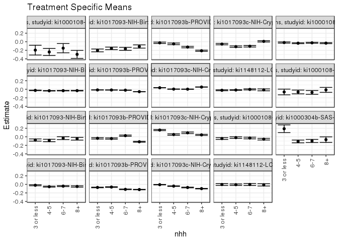

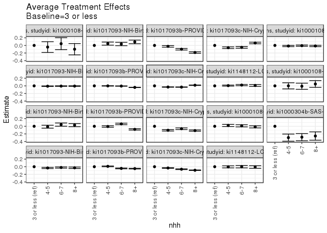

## Results Table

### Parameter: TSM

| agecat | studyid | country | intervention_level | baseline_level | estimate | ci_lower | ci_upper |
| --- | --- | --- | --- | --- | --- | --- | --- |
| 0-3 months | ki1000108-IRC | INDIA | 3 or less | NA | -0.1962914 | -0.3113576 | -0.0812252 |
| 0-3 months | ki1000108-IRC | INDIA | 4-5 | NA | -0.2398969 | -0.3221276 | -0.1576661 |
| 0-3 months | ki1000108-IRC | INDIA | 6-7 | NA | -0.1505699 | -0.2585751 | -0.0425646 |
| 0-3 months | ki1000108-IRC | INDIA | 8+ | NA | -0.2956969 | -0.3894685 | -0.2019253 |
| 0-3 months | ki1017093-NIH-Birth | BANGLADESH | 3 or less | NA | -0.2032207 | -0.2358242 | -0.1706173 |
| 0-3 months | ki1017093-NIH-Birth | BANGLADESH | 4-5 | NA | -0.1555032 | -0.1850836 | -0.1259229 |
| 0-3 months | ki1017093-NIH-Birth | BANGLADESH | 6-7 | NA | -0.1660302 | -0.2008523 | -0.1312081 |
| 0-3 months | ki1017093-NIH-Birth | BANGLADESH | 8+ | NA | -0.1111851 | -0.1493719 | -0.0729984 |
| 0-3 months | ki1017093b-PROVIDE | BANGLADESH | 3 or less | NA | -0.0252022 | -0.0417861 | -0.0086183 |
| 0-3 months | ki1017093b-PROVIDE | BANGLADESH | 4-5 | NA | -0.0495198 | -0.0681562 | -0.0308835 |
| 0-3 months | ki1017093b-PROVIDE | BANGLADESH | 6-7 | NA | -0.1248957 | -0.1422744 | -0.1075169 |
| 0-3 months | ki1017093b-PROVIDE | BANGLADESH | 8+ | NA | -0.2109998 | -0.2249725 | -0.1970271 |
| 0-3 months | ki1017093c-NIH-Crypto | BANGLADESH | 3 or less | NA | -0.0551294 | -0.0711765 | -0.0390824 |
| 0-3 months | ki1017093c-NIH-Crypto | BANGLADESH | 4-5 | NA | -0.1145833 | -0.1319792 | -0.0971873 |
| 0-3 months | ki1017093c-NIH-Crypto | BANGLADESH | 6-7 | NA | -0.1063908 | -0.1244317 | -0.0883499 |
| 0-3 months | ki1017093c-NIH-Crypto | BANGLADESH | 8+ | NA | 0.0085076 | -0.0071245 | 0.0241396 |
| 3-6 months | ki1000108-IRC | INDIA | 3 or less | NA | -0.0628905 | -0.1302294 | 0.0044483 |
| 3-6 months | ki1000108-IRC | INDIA | 4-5 | NA | -0.0630112 | -0.1078555 | -0.0181668 |
| 3-6 months | ki1000108-IRC | INDIA | 6-7 | NA | -0.0737441 | -0.1183768 | -0.0291115 |
| 3-6 months | ki1000108-IRC | INDIA | 8+ | NA | -0.0139754 | -0.0718158 | 0.0438651 |
| 3-6 months | ki1017093-NIH-Birth | BANGLADESH | 3 or less | NA | -0.0752922 | -0.1010783 | -0.0495061 |
| 3-6 months | ki1017093-NIH-Birth | BANGLADESH | 4-5 | NA | -0.0859654 | -0.1144698 | -0.0574611 |
| 3-6 months | ki1017093-NIH-Birth | BANGLADESH | 6-7 | NA | -0.0312707 | -0.0645816 | 0.0020403 |
| 3-6 months | ki1017093-NIH-Birth | BANGLADESH | 8+ | NA | -0.0447227 | -0.0763226 | -0.0131228 |
| 3-6 months | ki1017093b-PROVIDE | BANGLADESH | 3 or less | NA | -0.0351517 | -0.0513572 | -0.0189462 |
| 3-6 months | ki1017093b-PROVIDE | BANGLADESH | 4-5 | NA | -0.0408596 | -0.0561261 | -0.0255932 |
| 3-6 months | ki1017093b-PROVIDE | BANGLADESH | 6-7 | NA | 0.0272374 | 0.0126006 | 0.0418742 |
| 3-6 months | ki1017093b-PROVIDE | BANGLADESH | 8+ | NA | -0.1161295 | -0.1263973 | -0.1058618 |
| 3-6 months | ki1017093c-NIH-Crypto | BANGLADESH | 3 or less | NA | 0.1580292 | 0.1440346 | 0.1720239 |
| 3-6 months | ki1017093c-NIH-Crypto | BANGLADESH | 4-5 | NA | 0.0530567 | 0.0365151 | 0.0695984 |
| 3-6 months | ki1017093c-NIH-Crypto | BANGLADESH | 6-7 | NA | 0.0942986 | 0.0756019 | 0.1129952 |
| 3-6 months | ki1017093c-NIH-Crypto | BANGLADESH | 8+ | NA | 0.0454034 | 0.0328337 | 0.0579732 |
| 6-12 months | ki1000108-IRC | INDIA | 3 or less | NA | -0.0399097 | -0.0610500 | -0.0187695 |
| 6-12 months | ki1000108-IRC | INDIA | 4-5 | NA | -0.0182794 | -0.0366747 | 0.0001160 |
| 6-12 months | ki1000108-IRC | INDIA | 6-7 | NA | -0.0280333 | -0.0475939 | -0.0084728 |
| 6-12 months | ki1000108-IRC | INDIA | 8+ | NA | -0.0550378 | -0.0738275 | -0.0362481 |
| 6-12 months | ki1000304b-SAS-FoodSuppl | INDIA | 3 or less | NA | 0.1892224 | 0.0991418 | 0.2793029 |
| 6-12 months | ki1000304b-SAS-FoodSuppl | INDIA | 4-5 | NA | -0.1084946 | -0.1412332 | -0.0757561 |
| 6-12 months | ki1000304b-SAS-FoodSuppl | INDIA | 6-7 | NA | -0.0967379 | -0.1329703 | -0.0605055 |
| 6-12 months | ki1000304b-SAS-FoodSuppl | INDIA | 8+ | NA | -0.0660919 | -0.1310136 | -0.0011703 |
| 6-12 months | ki1017093-NIH-Birth | BANGLADESH | 3 or less | NA | -0.0214768 | -0.0337424 | -0.0092112 |
| 6-12 months | ki1017093-NIH-Birth | BANGLADESH | 4-5 | NA | -0.0543340 | -0.0660341 | -0.0426340 |
| 6-12 months | ki1017093-NIH-Birth | BANGLADESH | 6-7 | NA | -0.0424823 | -0.0540395 | -0.0309250 |
| 6-12 months | ki1017093-NIH-Birth | BANGLADESH | 8+ | NA | -0.0499758 | -0.0660880 | -0.0338637 |
| 6-12 months | ki1017093b-PROVIDE | BANGLADESH | 3 or less | NA | -0.0725566 | -0.0795561 | -0.0655572 |
| 6-12 months | ki1017093b-PROVIDE | BANGLADESH | 4-5 | NA | -0.0629757 | -0.0702813 | -0.0556701 |
| 6-12 months | ki1017093b-PROVIDE | BANGLADESH | 6-7 | NA | -0.1171914 | -0.1247487 | -0.1096341 |
| 6-12 months | ki1017093b-PROVIDE | BANGLADESH | 8+ | NA | -0.1223973 | -0.1278472 | -0.1169475 |
| 6-12 months | ki1017093c-NIH-Crypto | BANGLADESH | 3 or less | NA | -0.0075839 | -0.0133500 | -0.0018177 |
| 6-12 months | ki1017093c-NIH-Crypto | BANGLADESH | 4-5 | NA | -0.0414505 | -0.0485471 | -0.0343539 |
| 6-12 months | ki1017093c-NIH-Crypto | BANGLADESH | 6-7 | NA | -0.0734198 | -0.0817177 | -0.0651218 |
| 6-12 months | ki1017093c-NIH-Crypto | BANGLADESH | 8+ | NA | -0.1001916 | -0.1063192 | -0.0940641 |
| 6-12 months | ki1148112-LCNI-5 | MALAWI | 3 or less | NA | -0.0039147 | -0.0250060 | 0.0171765 |
| 6-12 months | ki1148112-LCNI-5 | MALAWI | 4-5 | NA | -0.0072170 | -0.0245447 | 0.0101108 |
| 6-12 months | ki1148112-LCNI-5 | MALAWI | 6-7 | NA | -0.0031501 | -0.0262190 | 0.0199187 |
| 6-12 months | ki1148112-LCNI-5 | MALAWI | 8+ | NA | -0.0114847 | -0.0382453 | 0.0152759 |
| 12-24 months | ki1000108-IRC | INDIA | 3 or less | NA | -0.0191871 | -0.0327892 | -0.0055850 |
| 12-24 months | ki1000108-IRC | INDIA | 4-5 | NA | -0.0344919 | -0.0445072 | -0.0244765 |
| 12-24 months | ki1000108-IRC | INDIA | 6-7 | NA | -0.0251620 | -0.0362255 | -0.0140986 |
| 12-24 months | ki1000108-IRC | INDIA | 8+ | NA | -0.0332046 | -0.0448763 | -0.0215329 |
| 12-24 months | ki1017093-NIH-Birth | BANGLADESH | 3 or less | NA | -0.0263360 | -0.0327506 | -0.0199214 |
| 12-24 months | ki1017093-NIH-Birth | BANGLADESH | 4-5 | NA | -0.0355545 | -0.0411448 | -0.0299642 |
| 12-24 months | ki1017093-NIH-Birth | BANGLADESH | 6-7 | NA | -0.0328813 | -0.0384652 | -0.0272974 |
| 12-24 months | ki1017093-NIH-Birth | BANGLADESH | 8+ | NA | -0.0324759 | -0.0392383 | -0.0257135 |
| 12-24 months | ki1017093b-PROVIDE | BANGLADESH | 3 or less | NA | -0.0153701 | -0.0186901 | -0.0120500 |
| 12-24 months | ki1017093b-PROVIDE | BANGLADESH | 4-5 | NA | -0.0168048 | -0.0209436 | -0.0126661 |
| 12-24 months | ki1017093b-PROVIDE | BANGLADESH | 6-7 | NA | -0.0211107 | -0.0244299 | -0.0177915 |
| 12-24 months | ki1017093b-PROVIDE | BANGLADESH | 8+ | NA | -0.0561911 | -0.0595172 | -0.0528651 |
| 12-24 months | ki1017093c-NIH-Crypto | BANGLADESH | 3 or less | NA | 0.0356245 | 0.0319925 | 0.0392566 |
| 12-24 months | ki1017093c-NIH-Crypto | BANGLADESH | 4-5 | NA | 0.0039953 | -0.0002354 | 0.0082259 |
| 12-24 months | ki1017093c-NIH-Crypto | BANGLADESH | 6-7 | NA | 0.0023424 | -0.0016254 | 0.0063101 |
| 12-24 months | ki1017093c-NIH-Crypto | BANGLADESH | 8+ | NA | 0.0523398 | 0.0483500 | 0.0563297 |
| 12-24 months | ki1148112-LCNI-5 | MALAWI | 3 or less | NA | -0.0236626 | -0.0341445 | -0.0131807 |
| 12-24 months | ki1148112-LCNI-5 | MALAWI | 4-5 | NA | -0.0175459 | -0.0262359 | -0.0088558 |
| 12-24 months | ki1148112-LCNI-5 | MALAWI | 6-7 | NA | -0.0032726 | -0.0162459 | 0.0097008 |
| 12-24 months | ki1148112-LCNI-5 | MALAWI | 8+ | NA | -0.0139250 | -0.0361657 | 0.0083158 |

### Parameter: E(Y)

| agecat | studyid | country | intervention_level | baseline_level | estimate | ci_lower | ci_upper |
| --- | --- | --- | --- | --- | --- | --- | --- |
| 0-3 months | ki1000108-IRC | INDIA | NA | NA | -0.2594964 | -0.3154509 | -0.2035418 |
| 0-3 months | ki1017093-NIH-Birth | BANGLADESH | NA | NA | -0.1191165 | -0.1460676 | -0.0921654 |
| 0-3 months | ki1017093b-PROVIDE | BANGLADESH | NA | NA | -0.0413143 | -0.0594662 | -0.0231624 |
| 0-3 months | ki1017093c-NIH-Crypto | BANGLADESH | NA | NA | -0.1220821 | -0.1402761 | -0.1038881 |
| 3-6 months | ki1000108-IRC | INDIA | NA | NA | -0.0518918 | -0.0819849 | -0.0217987 |
| 3-6 months | ki1017093-NIH-Birth | BANGLADESH | NA | NA | -0.0509007 | -0.0730097 | -0.0287917 |
| 3-6 months | ki1017093b-PROVIDE | BANGLADESH | NA | NA | -0.0272428 | -0.0436954 | -0.0107902 |
| 3-6 months | ki1017093c-NIH-Crypto | BANGLADESH | NA | NA | 0.0267740 | 0.0099602 | 0.0435879 |
| 6-12 months | ki1000108-IRC | INDIA | NA | NA | -0.0260151 | -0.0389122 | -0.0131180 |
| 6-12 months | ki1000304b-SAS-FoodSuppl | INDIA | NA | NA | -0.1080113 | -0.1390238 | -0.0769988 |
| 6-12 months | ki1017093-NIH-Birth | BANGLADESH | NA | NA | -0.0530976 | -0.0624028 | -0.0437924 |
| 6-12 months | ki1017093b-PROVIDE | BANGLADESH | NA | NA | -0.0626151 | -0.0695574 | -0.0556729 |
| 6-12 months | ki1017093c-NIH-Crypto | BANGLADESH | NA | NA | -0.0315658 | -0.0388594 | -0.0242722 |
| 6-12 months | ki1148112-LCNI-5 | MALAWI | NA | NA | -0.0067938 | -0.0177737 | 0.0041862 |
| 12-24 months | ki1000108-IRC | INDIA | NA | NA | -0.0317687 | -0.0388357 | -0.0247017 |
| 12-24 months | ki1017093-NIH-Birth | BANGLADESH | NA | NA | -0.0404278 | -0.0450901 | -0.0357656 |
| 12-24 months | ki1017093b-PROVIDE | BANGLADESH | NA | NA | -0.0081718 | -0.0120131 | -0.0043304 |
| 12-24 months | ki1017093c-NIH-Crypto | BANGLADESH | NA | NA | -0.0057326 | -0.0097260 | -0.0017391 |
| 12-24 months | ki1148112-LCNI-5 | MALAWI | NA | NA | -0.0160605 | -0.0218715 | -0.0102495 |

### Parameter: ATE

| agecat | studyid | country | intervention_level | baseline_level | estimate | ci_lower | ci_upper |
| --- | --- | --- | --- | --- | --- | --- | --- |
| 0-3 months | ki1000108-IRC | INDIA | 3 or less | 3 or less | 0.0000000 | 0.0000000 | 0.0000000 |
| 0-3 months | ki1000108-IRC | INDIA | 4-5 | 3 or less | -0.0436054 | -0.1849581 | 0.0977473 |
| 0-3 months | ki1000108-IRC | INDIA | 6-7 | 3 or less | 0.0457215 | -0.1115713 | 0.2030144 |
| 0-3 months | ki1000108-IRC | INDIA | 8+ | 3 or less | -0.0994055 | -0.2482071 | 0.0493962 |
| 0-3 months | ki1017093-NIH-Birth | BANGLADESH | 3 or less | 3 or less | 0.0000000 | 0.0000000 | 0.0000000 |
| 0-3 months | ki1017093-NIH-Birth | BANGLADESH | 4-5 | 3 or less | 0.0477175 | 0.0066747 | 0.0887603 |
| 0-3 months | ki1017093-NIH-Birth | BANGLADESH | 6-7 | 3 or less | 0.0371905 | -0.0075334 | 0.0819144 |
| 0-3 months | ki1017093-NIH-Birth | BANGLADESH | 8+ | 3 or less | 0.0920356 | 0.0435443 | 0.1405268 |
| 0-3 months | ki1017093b-PROVIDE | BANGLADESH | 3 or less | 3 or less | 0.0000000 | 0.0000000 | 0.0000000 |
| 0-3 months | ki1017093b-PROVIDE | BANGLADESH | 4-5 | 3 or less | -0.0243177 | -0.0468099 | -0.0018254 |
| 0-3 months | ki1017093b-PROVIDE | BANGLADESH | 6-7 | 3 or less | -0.0996935 | -0.1215556 | -0.0778314 |
| 0-3 months | ki1017093b-PROVIDE | BANGLADESH | 8+ | 3 or less | -0.1857976 | -0.2052499 | -0.1663453 |
| 0-3 months | ki1017093c-NIH-Crypto | BANGLADESH | 3 or less | 3 or less | 0.0000000 | 0.0000000 | 0.0000000 |
| 0-3 months | ki1017093c-NIH-Crypto | BANGLADESH | 4-5 | 3 or less | -0.0594538 | -0.0813161 | -0.0375915 |
| 0-3 months | ki1017093c-NIH-Crypto | BANGLADESH | 6-7 | 3 or less | -0.0512613 | -0.0740677 | -0.0284550 |
| 0-3 months | ki1017093c-NIH-Crypto | BANGLADESH | 8+ | 3 or less | 0.0636370 | 0.0423167 | 0.0849573 |
| 3-6 months | ki1000108-IRC | INDIA | 3 or less | 3 or less | 0.0000000 | 0.0000000 | 0.0000000 |
| 3-6 months | ki1000108-IRC | INDIA | 4-5 | 3 or less | -0.0001206 | -0.0807897 | 0.0805485 |
| 3-6 months | ki1000108-IRC | INDIA | 6-7 | 3 or less | -0.0108536 | -0.0915949 | 0.0698877 |
| 3-6 months | ki1000108-IRC | INDIA | 8+ | 3 or less | 0.0489152 | -0.0397501 | 0.1375805 |
| 3-6 months | ki1017093-NIH-Birth | BANGLADESH | 3 or less | 3 or less | 0.0000000 | 0.0000000 | 0.0000000 |
| 3-6 months | ki1017093-NIH-Birth | BANGLADESH | 4-5 | 3 or less | -0.0106732 | -0.0490155 | 0.0276690 |
| 3-6 months | ki1017093-NIH-Birth | BANGLADESH | 6-7 | 3 or less | 0.0440215 | 0.0019497 | 0.0860933 |
| 3-6 months | ki1017093-NIH-Birth | BANGLADESH | 8+ | 3 or less | 0.0305695 | -0.0101743 | 0.0713132 |
| 3-6 months | ki1017093b-PROVIDE | BANGLADESH | 3 or less | 3 or less | 0.0000000 | 0.0000000 | 0.0000000 |
| 3-6 months | ki1017093b-PROVIDE | BANGLADESH | 4-5 | 3 or less | -0.0057079 | -0.0258360 | 0.0144202 |
| 3-6 months | ki1017093b-PROVIDE | BANGLADESH | 6-7 | 3 or less | 0.0623891 | 0.0424246 | 0.0823536 |
| 3-6 months | ki1017093b-PROVIDE | BANGLADESH | 8+ | 3 or less | -0.0809778 | -0.0983891 | -0.0635665 |
| 3-6 months | ki1017093c-NIH-Crypto | BANGLADESH | 3 or less | 3 or less | 0.0000000 | 0.0000000 | 0.0000000 |
| 3-6 months | ki1017093c-NIH-Crypto | BANGLADESH | 4-5 | 3 or less | -0.1049725 | -0.1244649 | -0.0854801 |
| 3-6 months | ki1017093c-NIH-Crypto | BANGLADESH | 6-7 | 3 or less | -0.0637307 | -0.0851089 | -0.0423524 |
| 3-6 months | ki1017093c-NIH-Crypto | BANGLADESH | 8+ | 3 or less | -0.1126258 | -0.1303304 | -0.0949211 |
| 6-12 months | ki1000108-IRC | INDIA | 3 or less | 3 or less | 0.0000000 | 0.0000000 | 0.0000000 |
| 6-12 months | ki1000108-IRC | INDIA | 4-5 | 3 or less | 0.0216304 | -0.0058985 | 0.0491592 |
| 6-12 months | ki1000108-IRC | INDIA | 6-7 | 3 or less | 0.0118764 | -0.0165789 | 0.0403317 |
| 6-12 months | ki1000108-IRC | INDIA | 8+ | 3 or less | -0.0151281 | -0.0429086 | 0.0126524 |
| 6-12 months | ki1000304b-SAS-FoodSuppl | INDIA | 3 or less | 3 or less | 0.0000000 | 0.0000000 | 0.0000000 |
| 6-12 months | ki1000304b-SAS-FoodSuppl | INDIA | 4-5 | 3 or less | -0.2977170 | -0.3910328 | -0.2044013 |
| 6-12 months | ki1000304b-SAS-FoodSuppl | INDIA | 6-7 | 3 or less | -0.2859603 | -0.3800007 | -0.1919198 |
| 6-12 months | ki1000304b-SAS-FoodSuppl | INDIA | 8+ | 3 or less | -0.2553143 | -0.3646194 | -0.1460092 |
| 6-12 months | ki1017093-NIH-Birth | BANGLADESH | 3 or less | 3 or less | 0.0000000 | 0.0000000 | 0.0000000 |
| 6-12 months | ki1017093-NIH-Birth | BANGLADESH | 4-5 | 3 or less | -0.0328572 | -0.0497595 | -0.0159549 |
| 6-12 months | ki1017093-NIH-Birth | BANGLADESH | 6-7 | 3 or less | -0.0210054 | -0.0379102 | -0.0041007 |
| 6-12 months | ki1017093-NIH-Birth | BANGLADESH | 8+ | 3 or less | -0.0284990 | -0.0488060 | -0.0081921 |
| 6-12 months | ki1017093b-PROVIDE | BANGLADESH | 3 or less | 3 or less | 0.0000000 | 0.0000000 | 0.0000000 |
| 6-12 months | ki1017093b-PROVIDE | BANGLADESH | 4-5 | 3 or less | 0.0095809 | -0.0005145 | 0.0196764 |
| 6-12 months | ki1017093b-PROVIDE | BANGLADESH | 6-7 | 3 or less | -0.0446348 | -0.0550147 | -0.0342549 |
| 6-12 months | ki1017093b-PROVIDE | BANGLADESH | 8+ | 3 or less | -0.0498407 | -0.0588153 | -0.0408661 |
| 6-12 months | ki1017093c-NIH-Crypto | BANGLADESH | 3 or less | 3 or less | 0.0000000 | 0.0000000 | 0.0000000 |
| 6-12 months | ki1017093c-NIH-Crypto | BANGLADESH | 4-5 | 3 or less | -0.0338666 | -0.0420735 | -0.0256597 |
| 6-12 months | ki1017093c-NIH-Crypto | BANGLADESH | 6-7 | 3 or less | -0.0658359 | -0.0752306 | -0.0564412 |
| 6-12 months | ki1017093c-NIH-Crypto | BANGLADESH | 8+ | 3 or less | -0.0926078 | -0.1003912 | -0.0848244 |
| 6-12 months | ki1148112-LCNI-5 | MALAWI | 3 or less | 3 or less | 0.0000000 | 0.0000000 | 0.0000000 |
| 6-12 months | ki1148112-LCNI-5 | MALAWI | 4-5 | 3 or less | -0.0033022 | -0.0305496 | 0.0239452 |
| 6-12 months | ki1148112-LCNI-5 | MALAWI | 6-7 | 3 or less | 0.0007646 | -0.0304552 | 0.0319845 |
| 6-12 months | ki1148112-LCNI-5 | MALAWI | 8+ | 3 or less | -0.0075700 | -0.0416606 | 0.0265207 |
| 12-24 months | ki1000108-IRC | INDIA | 3 or less | 3 or less | 0.0000000 | 0.0000000 | 0.0000000 |
| 12-24 months | ki1000108-IRC | INDIA | 4-5 | 3 or less | -0.0153048 | -0.0319324 | 0.0013229 |
| 12-24 months | ki1000108-IRC | INDIA | 6-7 | 3 or less | -0.0059750 | -0.0234516 | 0.0115016 |
| 12-24 months | ki1000108-IRC | INDIA | 8+ | 3 or less | -0.0140175 | -0.0317721 | 0.0037370 |
| 12-24 months | ki1017093-NIH-Birth | BANGLADESH | 3 or less | 3 or less | 0.0000000 | 0.0000000 | 0.0000000 |
| 12-24 months | ki1017093-NIH-Birth | BANGLADESH | 4-5 | 3 or less | -0.0092186 | -0.0173944 | -0.0010427 |
| 12-24 months | ki1017093-NIH-Birth | BANGLADESH | 6-7 | 3 or less | -0.0065453 | -0.0148069 | 0.0017162 |
| 12-24 months | ki1017093-NIH-Birth | BANGLADESH | 8+ | 3 or less | -0.0061400 | -0.0151676 | 0.0028877 |
| 12-24 months | ki1017093b-PROVIDE | BANGLADESH | 3 or less | 3 or less | 0.0000000 | 0.0000000 | 0.0000000 |
| 12-24 months | ki1017093b-PROVIDE | BANGLADESH | 4-5 | 3 or less | -0.0014348 | -0.0065277 | 0.0036582 |
| 12-24 months | ki1017093b-PROVIDE | BANGLADESH | 6-7 | 3 or less | -0.0057406 | -0.0103607 | -0.0011206 |
| 12-24 months | ki1017093b-PROVIDE | BANGLADESH | 8+ | 3 or less | -0.0408211 | -0.0454496 | -0.0361925 |
| 12-24 months | ki1017093c-NIH-Crypto | BANGLADESH | 3 or less | 3 or less | 0.0000000 | 0.0000000 | 0.0000000 |
| 12-24 months | ki1017093c-NIH-Crypto | BANGLADESH | 4-5 | 3 or less | -0.0316293 | -0.0372336 | -0.0260249 |
| 12-24 months | ki1017093c-NIH-Crypto | BANGLADESH | 6-7 | 3 or less | -0.0332822 | -0.0387852 | -0.0277792 |
| 12-24 months | ki1017093c-NIH-Crypto | BANGLADESH | 8+ | 3 or less | 0.0167153 | 0.0108563 | 0.0225743 |
| 12-24 months | ki1148112-LCNI-5 | MALAWI | 3 or less | 3 or less | 0.0000000 | 0.0000000 | 0.0000000 |
| 12-24 months | ki1148112-LCNI-5 | MALAWI | 4-5 | 3 or less | 0.0061167 | -0.0074988 | 0.0197323 |
| 12-24 months | ki1148112-LCNI-5 | MALAWI | 6-7 | 3 or less | 0.0203901 | 0.0037115 | 0.0370686 |
| 12-24 months | ki1148112-LCNI-5 | MALAWI | 8+ | 3 or less | 0.0097376 | -0.0148493 | 0.0343246 |